# Voting patterns over time

#### A short work-up of U.S. Census data on voting proportions of voting-eligible citizenry

```r
voting = vroom('output/voting_rates.tsv')
```

```
Observations: 714
Variables: 4
chr [2]: state, type
dbl [2]: year, voting_rate

Call `spec()` for a copy-pastable column specification
```

```r
models = readRDS('output/model_tbl.RDS')

yr = substr(sort(voting$year), start = 3, stop = 4) %>% unique
```

## What is the slope and magnitude of the year coefficient of each state?

## ModelFits

### Interaction model

This model is a simple one that fits an individual intercept and slope for each state. It is suggestive of trend over time assuming that states are completely independent of one another. Using the slope coefficients we can quantify the trend over time for each state.

$$y \sim N(\mu, \sigma)\\
\mu = \beta_0 + \beta_1(year) + \beta_2(state) + \beta_3(state * year)$$

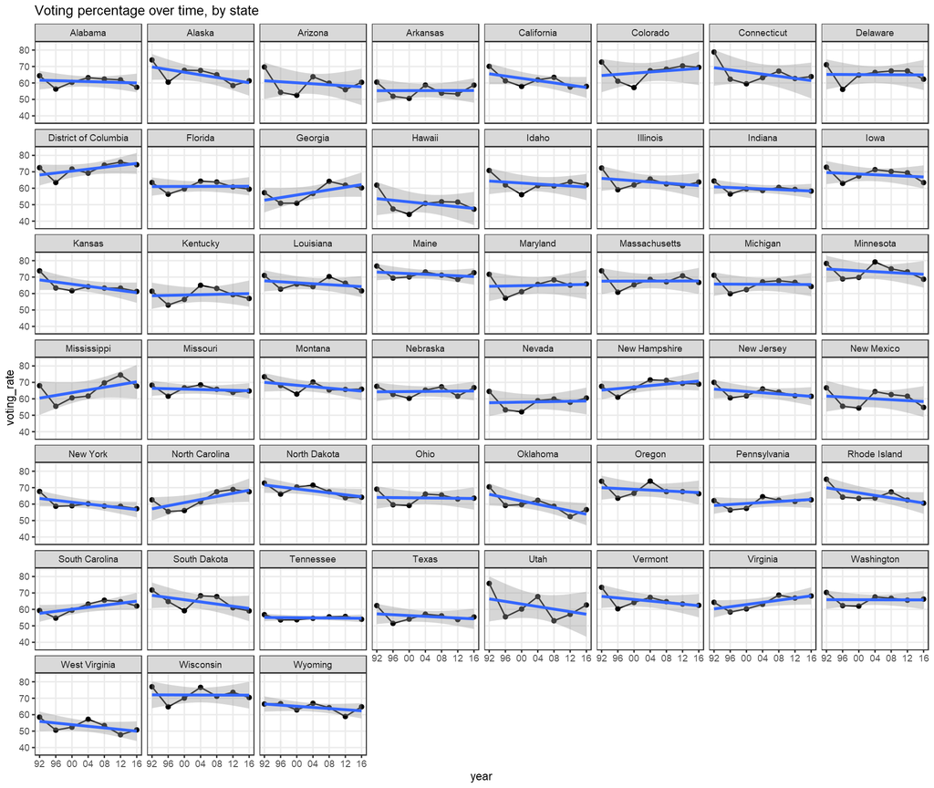

The fit for the interaction model:

```r
pick = which(models$description == "voting_rate ~ -1 + year * state")
mod  = models$model_fit[[pick]]
```

```r
slope_or_int = function(df) {
  df %>%  mutate(type = case_when(
  grepl(pattern = '(^year)', x = term) ~ 'slope',
  T ~ 'intercept'
))
}

tidy_interaction = models$model_fit[[pick]] %>% tidy %>% slope_or_int

slopes = filter(tidy_interaction, type == 'slope')
slopes = slopes %>% mutate(direction = case_when(
  estimate > 0 ~ "Increasing",
  estimate < 0 ~ "Decreasing"
))

kable(slopes, digits = 2)
```

| term | estimate | std.error | statistic | p.value | type | direction |
| --- | --- | --- | --- | --- | --- | --- |
| year | -0.07 | 0.20 | -0.35 | 0.72 | slope | Decreasing |
| year:stateAlaska | -0.33 | 0.28 | -1.18 | 0.24 | slope | Decreasing |
| year:stateArizona | -0.08 | 0.28 | -0.30 | 0.76 | slope | Decreasing |
| year:stateArkansas | 0.07 | 0.28 | 0.27 | 0.79 | slope | Increasing |
| year:stateCalifornia | -0.27 | 0.28 | -0.98 | 0.33 | slope | Decreasing |
| year:stateColorado | 0.25 | 0.28 | 0.90 | 0.37 | slope | Increasing |
| year:stateConnecticut | -0.25 | 0.28 | -0.91 | 0.36 | slope | Decreasing |
| year:stateDelaware | 0.06 | 0.28 | 0.20 | 0.84 | slope | Increasing |
| year:stateDistrict of Columbia | 0.36 | 0.28 | 1.30 | 0.20 | slope | Increasing |
| year:stateFlorida | 0.08 | 0.28 | 0.28 | 0.78 | slope | Increasing |
| year:stateGeorgia | 0.46 | 0.28 | 1.66 | 0.10 | slope | Increasing |
| year:stateHawaii | -0.18 | 0.28 | -0.64 | 0.52 | slope | Decreasing |
| year:stateIdaho | -0.08 | 0.28 | -0.30 | 0.77 | slope | Decreasing |
| year:stateIllinois | -0.11 | 0.28 | -0.40 | 0.69 | slope | Decreasing |
| year:stateIndiana | -0.04 | 0.28 | -0.13 | 0.90 | slope | Decreasing |
| year:stateIowa | -0.04 | 0.28 | -0.15 | 0.88 | slope | Decreasing |
| year:stateKansas | -0.25 | 0.28 | -0.91 | 0.37 | slope | Decreasing |
| year:stateKentucky | 0.12 | 0.28 | 0.44 | 0.66 | slope | Increasing |
| year:stateLouisiana | -0.08 | 0.28 | -0.27 | 0.79 | slope | Decreasing |
| year:stateMaine | -0.04 | 0.28 | -0.15 | 0.88 | slope | Decreasing |
| year:stateMaryland | 0.12 | 0.28 | 0.42 | 0.67 | slope | Increasing |
| year:stateMassachusetts | 0.08 | 0.28 | 0.27 | 0.79 | slope | Increasing |
| year:stateMichigan | 0.06 | 0.28 | 0.21 | 0.83 | slope | Increasing |
| year:stateMinnesota | -0.06 | 0.28 | -0.23 | 0.82 | slope | Decreasing |
| year:stateMississippi | 0.48 | 0.28 | 1.73 | 0.08 | slope | Increasing |
| year:stateMissouri | 0.01 | 0.28 | 0.03 | 0.98 | slope | Increasing |
| year:stateMontana | -0.15 | 0.28 | -0.54 | 0.59 | slope | Decreasing |
| year:stateNebraska | 0.09 | 0.28 | 0.33 | 0.74 | slope | Increasing |
| year:stateNevada | 0.11 | 0.28 | 0.41 | 0.68 | slope | Increasing |
| year:stateNew Hampshire | 0.30 | 0.28 | 1.07 | 0.29 | slope | Increasing |
| year:stateNew Jersey | -0.11 | 0.28 | -0.41 | 0.69 | slope | Decreasing |
| year:stateNew Mexico | -0.07 | 0.28 | -0.24 | 0.81 | slope | Decreasing |
| year:stateNew York | -0.21 | 0.28 | -0.76 | 0.45 | slope | Decreasing |
| year:stateNorth Carolina | 0.54 | 0.28 | 1.94 | 0.05 | slope | Increasing |
| year:stateNorth Dakota | -0.23 | 0.28 | -0.81 | 0.42 | slope | Decreasing |
| year:stateOhio | 0.04 | 0.28 | 0.15 | 0.88 | slope | Increasing |
| year:stateOklahoma | -0.43 | 0.28 | -1.55 | 0.12 | slope | Decreasing |
| year:stateOregon | -0.05 | 0.28 | -0.19 | 0.85 | slope | Decreasing |
| year:statePennsylvania | 0.22 | 0.28 | 0.79 | 0.43 | slope | Increasing |
| year:stateRhode Island | -0.32 | 0.28 | -1.13 | 0.26 | slope | Decreasing |
| year:stateSouth Carolina | 0.38 | 0.28 | 1.35 | 0.18 | slope | Increasing |
| year:stateSouth Dakota | -0.26 | 0.28 | -0.93 | 0.35 | slope | Decreasing |
| year:stateTennessee | 0.05 | 0.28 | 0.17 | 0.86 | slope | Increasing |
| year:stateTexas | -0.06 | 0.28 | -0.20 | 0.84 | slope | Decreasing |
| year:stateUtah | -0.32 | 0.28 | -1.14 | 0.26 | slope | Decreasing |
| year:stateVermont | -0.17 | 0.28 | -0.60 | 0.55 | slope | Decreasing |
| year:stateVirginia | 0.40 | 0.28 | 1.43 | 0.15 | slope | Increasing |
| year:stateWashington | 0.06 | 0.28 | 0.23 | 0.82 | slope | Increasing |
| year:stateWest Virginia | -0.18 | 0.28 | -0.64 | 0.52 | slope | Decreasing |
| year:stateWisconsin | 0.06 | 0.28 | 0.22 | 0.83 | slope | Increasing |
| year:stateWyoming | -0.10 | 0.28 | -0.37 | 0.71 | slope | Decreasing |

### Random effects model

A random intercept and slope is specified for each state, and a fixed effect by year. The variation in the year slope is small such that the estimated standard deviation of the population of coefficients is 0.004, and the simpler random intercept for each state model is more parsimonious by AIC. It suggests that the overall trend to decrease over time is adequately explained by the fixed effect for year and a random effect for state, and the slopes don’t actually have great variance by state under this model.

$$y \sim N(\mu, \sigma)\\
\mu = \beta_0 + \alpha_{0,s} + \alpha_{1,s}*year + \beta_1*year\\
\alpha_{0,s} \sim N(0,\Sigma)\\
\alpha_{1,s} \sim N(0,\Sigma)$$

Compare the output of the random intercepts & slope model (first) to just the random intercepts (second)

```r
pick = which(models$description == "voting_rate ~ year + (year | state)")
re_mod_1 = models$model_fit[[pick]]
re_mod_1
```

```
Linear mixed model fit by maximum likelihood  ['lmerMod']
Formula: voting_rate ~ year + (year | state)
   Data: voting
      AIC       BIC    logLik  deviance  df.resid
 2171.267  2194.534 -1079.634  2159.267       351
Random effects:
 Groups   Name        Std.Dev. Corr
 state    (Intercept) 4.263746
          year        0.004373 -1.00
 Residual             4.262765
Number of obs: 357, groups:  state, 51
Fixed Effects:
(Intercept)         year
  206.29527     -0.07132
convergence code 0; 1 optimizer warnings; 0 lme4 warnings
```

```r
pick = which(models$description == "voting_rate ~ year + (1 | state)")
re_mod_2 = models$model_fit[[pick]]
re_mod_2
```

```
Linear mixed model fit by maximum likelihood  ['lmerMod']
Formula: voting_rate ~ year + (1 | state)
   Data: voting
      AIC       BIC    logLik  deviance  df.resid
 2167.396  2182.906 -1079.698  2159.396       353
Random effects:
 Groups   Name        Std.Dev.
 state    (Intercept) 4.432
 Residual             4.273
Number of obs: 357, groups:  state, 51
Fixed Effects:
(Intercept)         year
  206.29527     -0.07132
```

Nevertheless, the functional difference of these models is minor; the fitted results are functionally identical.

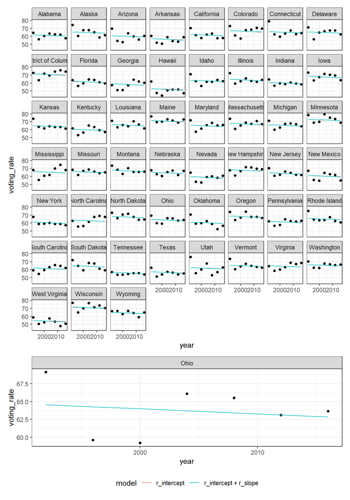

```r
augs = bind_rows(list("r_intercept + r_slope" = augment(re_mod_1), "r_intercept" = augment(re_mod_2)), .id = 'model')

overall = ggplot(augs) +
  geom_point(aes(x = year, y = voting_rate)) +
  geom_line(aes(x = year, y = .fitted, color = model)) +
  facet_wrap(~state)

one_state = ggplot(augs %>% filter(state == "Ohio")) +
  geom_point(aes(x = year, y = voting_rate)) +
  geom_line(aes(x = year, y = .fitted, color = model)) +
  facet_wrap(~state)

overall / one_state + plot_layout(heights = c(8,2), guides = 'collect') & theme_bw() & theme(legend.position = 'bottom')
```

### Random intercepts model – best performing by AIC

Here, a random intercept is specified for each state, but also each year. The year fixed effect is still included, but the random effects absorb most of the variation. It is interesting in its own right to observe that 1992 appears to be a year of notably high voter participation followed by a reduction and a stabilization, in aggregate. It implies a different story than the independent-state model, suggesting that states tend to behave similarly within years.

$$y \sim N(\mu, \sigma) \\
\mu = \beta_0 + \alpha_{0,s} + \alpha_{1,y} + \beta_2*year \\
\alpha_{0,s} \sim N(0,\Sigma)\\
\alpha_{1,y} \sim N(0,\Sigma)$$

```r
pick = which(models$description == "voting_rate ~ (1 | state) + (1 | year) + year")
re_mod_3 = models$model_fit[[pick]]
re_mod_3
```

```
Linear mixed model fit by maximum likelihood  ['lmerMod']
Formula: voting_rate ~ (1 | state) + (1 | year) + year
   Data: voting
      AIC       BIC    logLik  deviance  df.resid
1974.3877 1993.7764 -982.1939 1964.3877       352
Random effects:
 Groups   Name        Std.Dev.
 state    (Intercept) 4.616
 year     (Intercept) 2.884
 Residual             2.981
Number of obs: 357, groups:  state, 51; year, 7
Fixed Effects:
(Intercept)         year
  206.29527     -0.07132
```

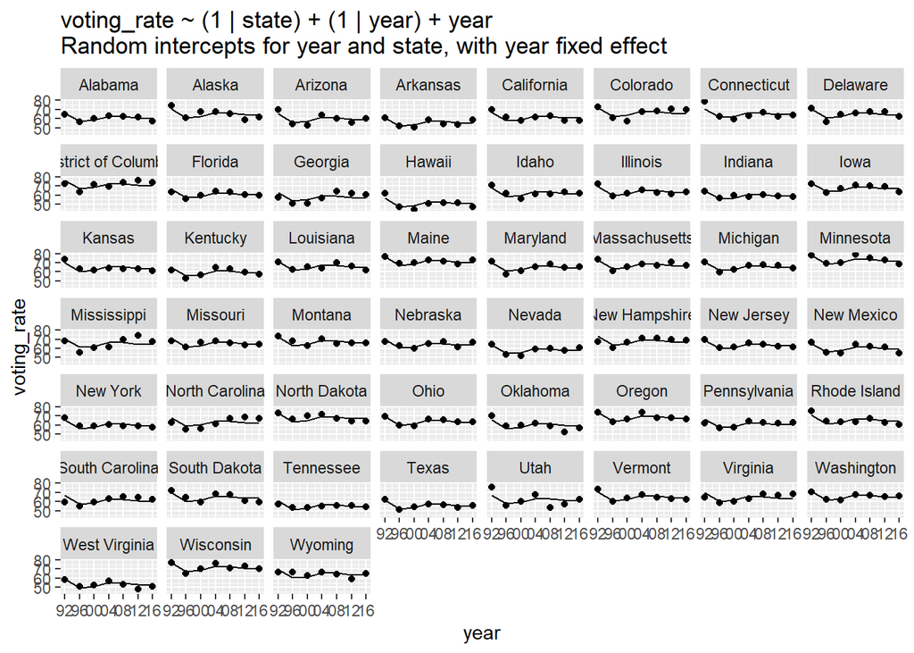

```r
aug = augment(re_mod_3)

ggplot(aug) +
  geom_point(aes(x = year, y = voting_rate)) +
  geom_line(aes(x = year, y = .fitted)) +
  scale_x_continuous(breaks = seq(1992, 2016,by=4), labels = yr)+
  facet_wrap(~state) +
  ggtitle('voting_rate ~ (1 | state) + (1 | year) + year\nRandom intercepts for year and state, with year fixed effect')
```

## Fitting the residuals of the random effect

Interestingly – when the residuals of the random effects model are fit, the slopes are identical to that of the ordinary interaction model. The standard error of the slope estimates are smaller in the random effects residual model.

Why is this?

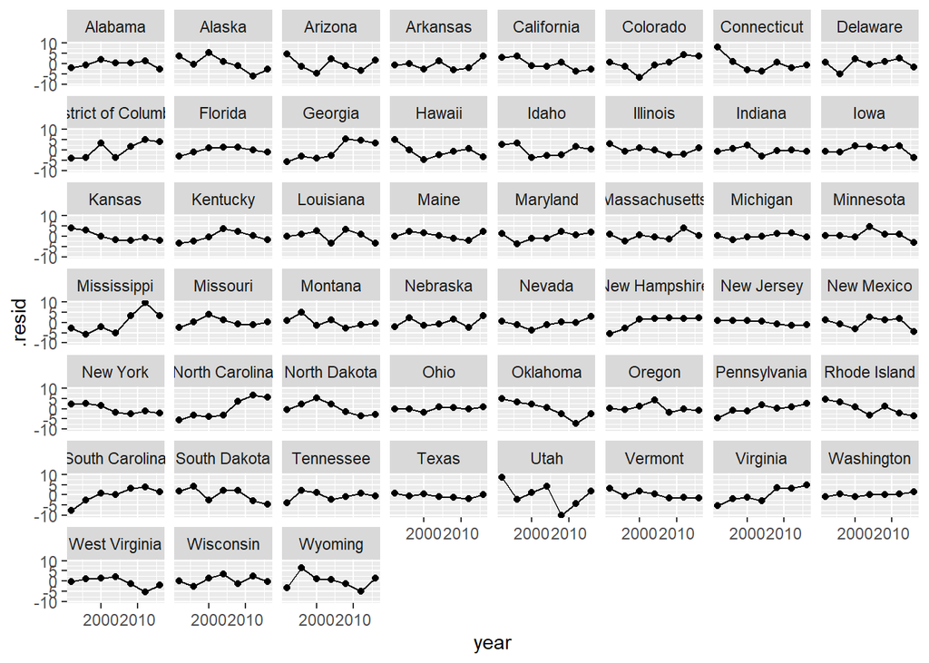

```r
# Plot residuals resulting from the random intercepts model (slope + year)

aug %>%
  ggplot() +
  geom_point(aes(x = year, y = .resid)) +
  geom_line(aes(x = year, y = .resid)) +
  facet_wrap(~state)
```

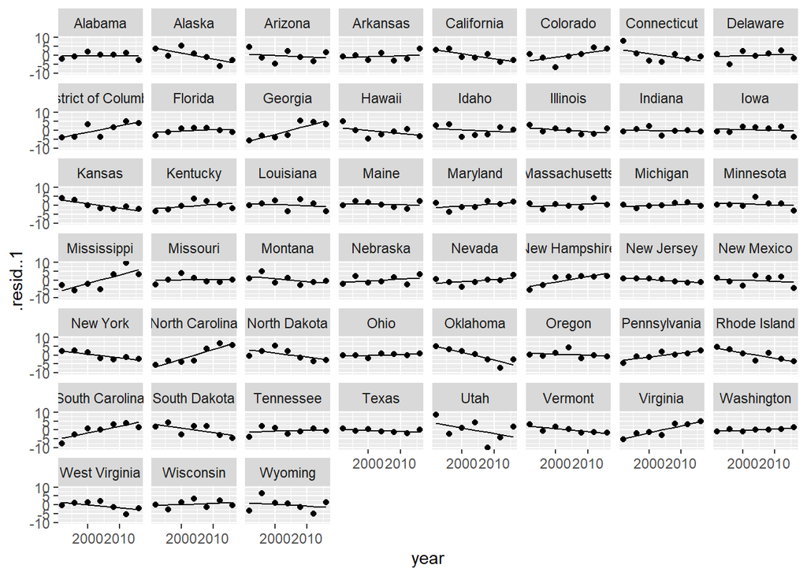

```r
aug_rn = aug %>% rename(.resid..1 = .resid) %>% as_tibble

mod2 = lm(data = aug_rn, formula = .resid..1 ~ year * state)

aug2 = augment(mod2)

aug2 %>% ggplot() +
  geom_point(aes(x = year, y = .resid..1)) +
  geom_line(aes(x = year, y = .fitted)) +
  facet_wrap(~state)
```

```r
tidy_mod2 = tidy(mod2) %>% slope_or_int %>% filter(type == 'slope')
tidy_mod  = tidy(mod) %>% slope_or_int %>% filter(type == 'slope')

tidy_mod %>% left_join(tidy_mod2, by = 'term', suffix = c("_lm", "_lmer")) %>%
  select(term, starts_with('estimate'), starts_with('std')) %>% print(n=65)
```

```
# A tibble: 51 x 5
   term                    estimate_lm estimate_lmer std.error_lm std.error_lmer
   <chr>                         <dbl>         <dbl>        <dbl>          <dbl>
 1 year                       -0.0701        0.00122        0.198          0.116
 2 year:stateAlaska           -0.331        -0.331          0.279          0.164
 3 year:stateArizona          -0.0844       -0.0844         0.279          0.164
 4 year:stateArkansas          0.0746        0.0746         0.279          0.164
 5 year:stateCalifornia       -0.275        -0.275          0.279          0.164
 6 year:stateColorado          0.250         0.250          0.279          0.164
 7 year:stateConnecticut      -0.254        -0.254          0.279          0.164
 8 year:stateDelaware          0.0567        0.0567         0.279          0.164
 9 year:stateDistrict of ~     0.362         0.362          0.279          0.164
10 year:stateFlorida           0.0778        0.0778         0.279          0.164
11 year:stateGeorgia           0.464         0.464          0.279          0.164
12 year:stateHawaii           -0.178        -0.178          0.279          0.164
```

[output cut: 39 more lines]